# Limpeza e Preparação dos Dados 🏗️ 🎲

## Sumário da Aula

- Reorganização 🗂️
- Limpeza 🧹
- Transformação 🛠️
- Juntando as Peças 🧩

## Aspectos de Reorganização, Limpeza e Transformação dos Dados

- 80% do tempo do analista de dados é investido em carga; reorganização; limpeza; e transformação.
- A maneira em que os dados estão armazenados em arquivos ou bancos de dados podem não corresponder ao formato apropriado para determinada tarefa;
- É comum o uso de linguagens de programação para transformar os dados de um formato para outro.

### Biblioteca Principal 📚: pandas

```python
import pandas as pd
```

### Reorganização 🗂️ dos Dados 🎲

#### Filtro 🍝 em Series 🎞️

```
Você pode filtrar os elementos de uma Serie de várias formas
```

```python
pibpc = pd.Series(data=[6797, 63123, 8476, 43258],
                  index=['Brasil', 'EUA', 'Argentina', 'Canada'])
pibpc
```

```
Brasil        6797
EUA          63123
Argentina     8476
Canada       43258
dtype: int64
```

```python
pibpc['EUA']
```

```
63123
```

```python
pibpc[1]
```

```
63123
```

```python
pibpc[2:4]
```

```
Argentina     8476
Canada       43258
dtype: int64
```

```python
pibpc[['EUA', 'Brasil', 'Canada']]
```

```
EUA       63123
Brasil     6797
Canada    43258
dtype: int64
```

```python
pibpc[[1, 3]]
```

```
EUA       63123
Canada    43258
dtype: int64
```

```python
pibpc[pibpc < 10000]
```

```
Brasil       6797
Argentina    8476
dtype: int64
```

👉 dica: dependendo do tipo de dados do índice da Series, utilizar inteiro entre colchetes **[ ]** pode ser confuso.  
O inteiro se refere ao valor do índice ou à posição da sequência no índice? Na dúvida, tenha preferência por usar as funções:

- **loc**: usa o valor do índice como elemento de filtro; e
- **iloc**: usa a posição da sequência no índice como elemento de filtro.

```python
pibpc.loc[['Brasil', 'EUA']]
```

```
Brasil     6797
EUA       63123
dtype: int64
```

```python
pibpc.iloc[[0, 1]]
```

```
Brasil     6797
EUA       63123
dtype: int64
```

#### Seleção 🍕 e Filtro 🍝 em DataFrame 📽️

```python
# Vamos analisar alguns dados de orgãos superiores do governo (ano 2022)
# https://portaldatransparencia.gov.br/orgaos-superiores?ano=2022

ministerios = ['Educacao', 'Saude', 'Fazenda', 'Agricultura']
servidores = [374_209, 44_762, 50_820, 15_275]
folha_pagamento = [29_905, 4_015, 3_002, 2_741] # em R$ 1.000.000
valor_arrecadado = [34_622, 2_430, 3_434_537, 6_128] # em R$ 1.000.000
despesa = [139_593, 143_251, 2_308_118, 13_663] # em R$ 1.000.000
```

```python
df = pd.DataFrame({
    'Servidores': servidores,
    'Folha de Pagamento': folha_pagamento,
    'Valor Arrecadado': valor_arrecadado,
    'Despesa': despesa
}, index = ministerios)

df
```

|  | Servidores | Folha de Pagamento | Valor Arrecadado | Despesa |
| --- | --- | --- | --- | --- |
| Educacao | 374209 | 29905 | 34622 | 139593 |
| Saude | 44762 | 4015 | 2430 | 143251 |
| Fazenda | 50820 | 3002 | 3434537 | 2308118 |
| Agricultura | 15275 | 2741 | 6128 | 13663 |

```
 Você pode selecionar uma coluna de um DataFrame pelo nome da coluna -- e retornar Serie
```

```python
df['Folha de Pagamento']
```

```
Educacao       29905
Saude           4015
Fazenda         3002
Agricultura     2741
Name: Folha de Pagamento, dtype: int64
```

```
Você pode selecionar colunas de um DataFrame pela lista dos nomes das colunas -- e retornar DataFrame
```

```python
df[['Valor Arrecadado', 'Servidores']]
```

|  | Valor Arrecadado | Servidores |
| --- | --- | --- |
| Educacao | 34622 | 374209 |
| Saude | 2430 | 44762 |
| Fazenda | 3434537 | 50820 |
| Agricultura | 6128 | 15275 |

```
Você pode filtrar linhas de um DataFrame com slicing -- e retornar DataFrame
```

```python
df[:2]
```

|  | Servidores | Folha de Pagamento | Valor Arrecadado | Despesa |
| --- | --- | --- | --- | --- |
| Educacao | 374209 | 29905 | 34622 | 139593 |
| Saude | 44762 | 4015 | 2430 | 143251 |

```
Você pode combinar seleção e filtro de um DataFrame com boolean indexing -- e retornar DataFrame
```

```python
df[df['Servidores'] > 50000]
```

|  | Servidores | Folha de Pagamento | Valor Arrecadado | Despesa |
| --- | --- | --- | --- | --- |
| Educacao | 374209 | 29905 | 34622 | 139593 |
| Fazenda | 50820 | 3002 | 3434537 | 2308118 |

```
🍒 🎂 Você pode inclusive atribuir um valor às células filtradas pela operação imediatamente acima
```

```python
df[df['Servidores'] > 50000] = 0
df
```

|  | Servidores | Folha de Pagamento | Valor Arrecadado | Despesa |
| --- | --- | --- | --- | --- |
| Educacao | 0 | 0 | 0 | 0 |
| Saude | 44762 | 4015 | 2430 | 143251 |
| Fazenda | 0 | 0 | 0 | 0 |
| Agricultura | 15275 | 2741 | 6128 | 13663 |

👉 dica: dependendo do tipo de dados do índice do DataFrame, utilizar inteiro entre colchetes **[ ]** pode ser confuso.  
O inteiro se refere ao valor do índice ou à posição da sequência no índice? na dúvida, tenha preferência por usar as funções:

- **loc**: usa o valor do índice como elemento de filtro; e
- **iloc**: usa a posição da sequência no índice como elemento de filtro.

```
Com loc, você pode ...
```

```
... filtrar uma linha de um DataFrame pelo nome da linha -- e retornar Serie...
```

```python
df.loc['Saude']
```

```
Servidores             44762
Folha de Pagamento      4015
Valor Arrecadado        2430
Despesa               143251
Name: Saude, dtype: int64
```

```
... filtrar linhas de um DataFrame pela lista dos nomes das linhas -- e retornar DataFrame...
```

```python
df.loc[["Saude", "Agricultura"]]
```

|  | Servidores | Folha de Pagamento | Valor Arrecadado | Despesa |
| --- | --- | --- | --- | --- |
| Saude | 44762 | 4015 | 2430 | 143251 |
| Agricultura | 15275 | 2741 | 6128 | 13663 |

```
... combinar seleção e filtro de um DataFrame -- com vírgula separando linhas de colunas...
```

```python
df.loc["Saude", ["Folha de Pagamento", "Valor Arrecadado"]]
```

```
Folha de Pagamento    4015
Valor Arrecadado      2430
Name: Saude, dtype: int64
```

```
Igualmente, com iloc, você pode repetir a sequência de operações imediatamente acima
```

```python
df.iloc[1]
```

```
Servidores             44762
Folha de Pagamento      4015
Valor Arrecadado        2430
Despesa               143251
Name: Saude, dtype: int64
```

```python
df.iloc[[1, 3]]
```

|  | Servidores | Folha de Pagamento | Valor Arrecadado | Despesa |
| --- | --- | --- | --- | --- |
| Saude | 44762 | 4015 | 2430 | 143251 |
| Agricultura | 15275 | 2741 | 6128 | 13663 |

```python
df.iloc[3, [3, 0, 1]]
```

```
Despesa               13663
Servidores            15275
Folha de Pagamento     2741
Name: Agricultura, dtype: int64
```

```python
df.iloc[[1, 2], [3, 0, 1]]
```

|  | Despesa | Servidores | Folha de Pagamento |
| --- | --- | --- | --- |
| Saude | 143251 | 44762 | 4015 |
| Fazenda | 0 | 0 | 0 |

##### Quadro-resumo dos métodos de Seleção 🍕 e Filtro 🍝 em DataFrame 📽️

Opção

Descrição

df[column]

Selecione uma única coluna ou sequência de colunas do DataFrame;  
Os casos especiais:

1. Vetor booleano: filtra linhas;
2. Slice: fatia linhas; e
3. DataFrame booleano: atribui valores com base em critérios.

df.loc[rows]

Selecione uma única linha ou subconjunto de linhas do DataFrame pelos rótulos do índices

df.loc[:, cols]

Selecione uma única coluna ou subconjunto de colunas pelos rótulo dos índices

df.loc[rows, cols]

Selecione linha(s) e coluna(s) pelos rótulos do índices

df.iloc[rows]

Selecione uma única linha ou subconjunto de linhas do DataFrame pela posição na sequência do índice

df.iloc[:, cols]

Selecione uma única coluna ou subconjunto de colunas pela posições nas sequências dos índices

df.iloc[rows, cols]

Selecione tanto linha(s) quanto coluna(s) pela posições nas sequências dos índices

df.at[row, col]

Selecione um único valor escalar pelos rótulos do índices

df.iat[row, col]

Selecione um único valor escalar pela posições nas sequências dos índices

reindex method

Selecione linhas ou colunas pelos rótulos do índices

### Limpeza 🧹 dos Dados 🎲

[figure not shown]

```
Veremos, a seguir, operações que serão utilizadas para contemplar os itens da lista de verificação de limpeza de dados 👆.
```

#### Dados Ausentes

Dados ausentes são comuns em muitas análises de dados; o pandas tem como objetivo trabalhar com dados ausentes com a menor "dor" possível.

Algumas das razões em termos dados ausentes:

- Falta da informação (Ex: países que não tem cultura de dados abertos)
- Erro de programação 🧑🏻‍💻
- Entrada de dados incorreta ❌
- Eventos arbitrários (feriados/problemas climáticos) 🎲

Nem sempre sua base de dados te indicará os dados ausentes. As vezes você terá que encontrá-los. Geralmente, estão representados da seguinte forma:

- NaN
- 999
- .
- ..
- ?
- faltante
- " "

O que devemos fazer com os Dados Ausentes?

- Substituir manualmente por valores significativos (NaN?);
- Filtrar/excluir a variável (coluna) ou a ocorrência (linha); ou
- Preencher/imputar valores (média, mediana, etc).

🚨 Tenha em mente que imputar valores é uma aproximação. Isso pode gerar viés para sua análise de dados.

```python
import numpy as np
```

```
Você pode representar o valor ausente para ponto flutuante com np.nan...
```

```python
servidores[1] = np.nan
servidores_s = pd.Series(servidores)
servidores_s
```

```
0    374209.0
1         NaN
2     50820.0
3     15275.0
dtype: float64
```

```
Veja que você pode identificar os valores não disponíveis (NA = Not Available), incluso o NaN (Not a Number)
```

```python
servidores_s.isna()
```

```
0    False
1     True
2    False
3    False
dtype: bool
```

```
ou com o próprio valor None do Python.
```

```python
ministerios[1] = None
ministerios_s = pd.Series(ministerios)
ministerios_s
```

```
0       Educacao
1           None
2        Fazenda
3    Agricultura
dtype: object
```

```python
ministerios_s.isna()
```

```
0    False
1     True
2    False
3    False
dtype: bool
```

```
 Você pode precisar transformar algum valor (no caso "..") em NaN.
```

```python
ministerios_s[2] = '..'
ministerios_s.replace('..', np.nan, inplace=True)
ministerios_s
```

```
0       Educacao
1           None
2            NaN
3    Agricultura
dtype: object
```

👉 dica: na ausência de *np.nan*, o *None* é automaticamente convertido para NaN

```python
servidores[1] = None
servidores
```

```
[374209, None, 50820, 15275]
```

```python
servidores_s = pd.Series(servidores)
servidores_s
```

```
0    374209.0
1         NaN
2     50820.0
3     15275.0
dtype: float64
```

```python
ministerios_s.isna()
```

```
0    False
1     True
2     True
3    False
dtype: bool
```

##### Filtrando Dados Ausentes

```
... com Series 🎞️
```

```python
servidores_s
```

```
0    374209.0
1         NaN
2     50820.0
3     15275.0
dtype: float64
```

```python
#equivalentemente, servidores_s[servidores_s.notna()]
servidores_s.dropna()
```

```
0    374209.0
2     50820.0
3     15275.0
dtype: float64
```

```
... com DataFrame 📽️...
```

```python
# Retomando o dataframe de dados dos orgãos superiores
# https://portaldatransparencia.gov.br/orgaos-superiores?ano=2022

df
```

|  | Servidores | Folha de Pagamento | Valor Arrecadado | Despesa |
| --- | --- | --- | --- | --- |
| Educacao | 0 | 0 | 0 | 0 |
| Saude | 44762 | 4015 | 2430 | 143251 |
| Fazenda | 0 | 0 | 0 | 0 |
| Agricultura | 15275 | 2741 | 6128 | 13663 |

```python
# Vamos inserir alguns NaN
df.iloc[2,:] = df.iloc[3,0] = df.iloc[0,1] = df.iloc[0,2] = np.nan
df
```

|  | Servidores | Folha de Pagamento | Valor Arrecadado | Despesa |
| --- | --- | --- | --- | --- |
| Educacao | 0.0 | NaN | NaN | 0.0 |
| Saude | 44762.0 | 4015.0 | 2430.0 | 143251.0 |
| Fazenda | NaN | NaN | NaN | NaN |
| Agricultura | NaN | 2741.0 | 6128.0 | 13663.0 |

```
... você pode excluir as linhas que tenham ao menos um valor ausente...
```

```python
df.dropna(how='any')
```

|  | Servidores | Folha de Pagamento | Valor Arrecadado | Despesa |
| --- | --- | --- | --- | --- |
| Saude | 44762.0 | 4015.0 | 2430.0 | 143251.0 |

```
... as linhas que tenham todos os valores ausentes...
```

```python
df.dropna(how="all")
```

|  | Servidores | Folha de Pagamento | Valor Arrecadado | Despesa |
| --- | --- | --- | --- | --- |
| Educacao | 0.0 | NaN | NaN | 0.0 |
| Saude | 44762.0 | 4015.0 | 2430.0 | 143251.0 |
| Agricultura | NaN | 2741.0 | 6128.0 | 13663.0 |

```
... ou qualquer número de ocorrências entre os extremos.
```

```python
df.dropna(thresh=3) #thresh = número mínimo de valores não ausentes
```

|  | Servidores | Folha de Pagamento | Valor Arrecadado | Despesa |
| --- | --- | --- | --- | --- |
| Saude | 44762.0 | 4015.0 | 2430.0 | 143251.0 |
| Agricultura | NaN | 2741.0 | 6128.0 | 13663.0 |

###### Quadro-resumo dos métodos para tratamento de *NA*

| Argumento | Descrição |
| --- | --- |
| dropna | Filtra rótulos de eixos, baseado no fato de os valores para cada rótulo terem dados ausentes, com limites variados para a quantidade de dados ausentes a ser tolerada. |
| fillna | Preenche os dados ausentes com algum valor ou utilizando um método de interpolação como 'ffill' ou 'bfill'. |
| isnull | Devolve valores booleanos informando quais valores estão ausentes/são NA. |
| notnull | Negação de isnull. |

##### Preenchendo Dados Ausentes

```
Veja que filtrar os dados ausentes pode incorrer em descartar outros dados (não-ausentes)
```

```
Portanto, alternativamente ao descarte, você pode preencher as lacunas (de dados ausentes) de várias maneiras:
```

```
por uma constante;
```

```python
df.fillna(0)
```

|  | Servidores | Folha de Pagamento | Valor Arrecadado | Despesa |
| --- | --- | --- | --- | --- |
| Educacao | 0.0 | 0.0 | 0.0 | 0.0 |
| Saude | 44762.0 | 4015.0 | 2430.0 | 143251.0 |
| Fazenda | 0.0 | 0.0 | 0.0 | 0.0 |
| Agricultura | 0.0 | 2741.0 | 6128.0 | 13663.0 |

```
por uma constante, de acordo com a coluna;
```

```python
df.fillna({'Servidores': 10_000, 'Folha de Pagamento': 3_000})
```

|  | Servidores | Folha de Pagamento | Valor Arrecadado | Despesa |
| --- | --- | --- | --- | --- |
| Educacao | 0.0 | 3000.0 | NaN | 0.0 |
| Saude | 44762.0 | 4015.0 | 2430.0 | 143251.0 |
| Fazenda | 10000.0 | 3000.0 | NaN | NaN |
| Agricultura | 10000.0 | 2741.0 | 6128.0 | 13663.0 |

```
por interpolação;
```

```python
df.fillna(method="ffill")
```

|  | Servidores | Folha de Pagamento | Valor Arrecadado | Despesa |
| --- | --- | --- | --- | --- |
| Educacao | 0.0 | NaN | NaN | 0.0 |
| Saude | 44762.0 | 4015.0 | 2430.0 | 143251.0 |
| Fazenda | 44762.0 | 4015.0 | 2430.0 | 143251.0 |
| Agricultura | 44762.0 | 2741.0 | 6128.0 | 13663.0 |

```
ou imputando dado por alguma medida de centralidade estatística, e.g. média.
```

```python
df.fillna(df.mean())
```

|  | Servidores | Folha de Pagamento | Valor Arrecadado | Despesa |
| --- | --- | --- | --- | --- |
| Educacao | 0.0 | 3378.0 | 4279.0 | 0.000000 |
| Saude | 44762.0 | 4015.0 | 2430.0 | 143251.000000 |
| Fazenda | 22381.0 | 3378.0 | 4279.0 | 52304.666667 |
| Agricultura | 22381.0 | 2741.0 | 6128.0 | 13663.000000 |

##### Quadro-resumo dos argumentos da função *fillna*

| Argumento | Descrição |
| --- | --- |
| value | Valor escalar ou um objeto do tipo dicionário a ser usado para preencher valores ausentes |
| method | Interpolação; por padrão, será 'ffill' se a função for chamada sem outros argumentos |
| axis | Eixo a ser preenchido; o default é axis=0 |
| inplace | Modifica o objeto que faz a chamada, sem gerar uma cópia |
| limit | Para preenchimento para a frente (forward) e para trás (backward), é o número máximo de valores consecutivos a serem preenchidos |

#### Eliminando Dados Duplicados

```
Alguns dados podem estar duplicados.
```

```python
data = pd.DataFrame({"k1": ["one", "two"] * 3 + ["two"], "k2": [1, 1, 2, 3, 3, 4, 4]})
data
```

|  | k1 | k2 |
| --- | --- | --- |
| 0 | one | 1 |
| 1 | two | 1 |
| 2 | one | 2 |
| 3 | two | 3 |
| 4 | one | 3 |
| 5 | two | 4 |
| 6 | two | 4 |

```
Você pode identificar os valores duplicados (considerando toda a linha)...
```

```python
data.duplicated()
```

```
0    False
1    False
2    False
3    False
4    False
5    False
6     True
dtype: bool
```

```
... e descartar as linhas repetidas...
```

```python
data.drop_duplicates()
```

|  | k1 | k2 |
| --- | --- | --- |
| 0 | one | 1 |
| 1 | two | 1 |
| 2 | one | 2 |
| 3 | two | 3 |
| 4 | one | 3 |
| 5 | two | 4 |

```
... ou descartar as linhas repetidas considerando parte das colunas.
```

👉 dica: o parâmetro *keep* pode ser usado para decidir qual ocorrência de linha duplicada será mantida

```python
data.drop_duplicates(subset=["k1"], keep='first') #tente keep='last'
```

|  | k1 | k2 |
| --- | --- | --- |
| 0 | one | 1 |
| 1 | two | 1 |

## Outliers

```
Outliers (valores discrepantes) são dados que se desviam do restante dos dados.
```

Outliers podem ser decorrentes de:

- ❌ Erros de entrada de dados ou de medida
- 🆕 Dados fora da curva (Ex: salário do jogador de futebol)
- 🧑🏻‍🔬 Manipulação de dados e erros de pré-processamento

👉 importante: outliers podem afetar a distribuição do conjunto de dados, afetar medidas de dispersão e prejudicar a análise de dados

### Detectando Outliers - Boxplot

```
Podemos usar boxplots para visualizar valores discrepantes em um conjunto de dados.
```

```python
# Retomando o dataframe de dados dos orgãos superiores
# https://portaldatransparencia.gov.br/orgaos-superiores?ano=2022

df
```

|  | Servidores | Folha de Pagamento | Valor Arrecadado | Despesa |
| --- | --- | --- | --- | --- |
| Educacao | 0.0 | NaN | NaN | 0.0 |
| Saude | 44762.0 | 4015.0 | 2430.0 | 143251.0 |
| Fazenda | NaN | NaN | NaN | NaN |
| Agricultura | NaN | 2741.0 | 6128.0 | 13663.0 |

```python
# Vamos inserir alguns outliers

df.loc['Educacao'] = [374_209, 29_905_000_000, 34_622, 139_593]
df.loc['Fazenda'] = [50_820, 3_002, 3_434_537, 2_308_118]
df.loc['Agricultura', 'Servidores'] = 15_275
df = df.astype('int64')
df
```

|  | Servidores | Folha de Pagamento | Valor Arrecadado | Despesa |
| --- | --- | --- | --- | --- |
| Educacao | 374209 | 29905000000 | 34622 | 139593 |
| Saude | 44762 | 4015 | 2430 | 143251 |
| Fazenda | 50820 | 3002 | 3434537 | 2308118 |
| Agricultura | 15275 | 2741 | 6128 | 13663 |

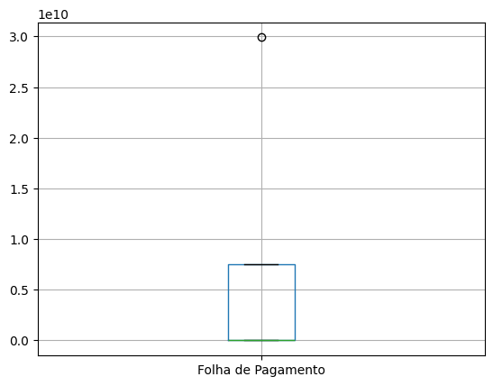

```python
df[['Folha de Pagamento']].boxplot();
```

```python
df['Folha de Pagamento'].max()
```

```
29905000000
```